# Plot data

# Installing the required packages.

In this lab, we will be using R to plot data onto maps. Before gettign started, we need to install a few packages. This can be done with command line:

```r
install.packages("PACKAGE_NAME")
```

Or using the graphical interface in RStudio: Tools -> Install packages.

The packages that we will need are: * ggplot2 * maps * mapdata * RColorBrewer

You can install all packages in one line of code with:

```r
install.packages( c("ggplot2", "maps", "mapdata", "RColorBrewer") )
```

Before we can start using the functions provided by these packages (but after we install them), we need to load the packages in memory (this step needs to be done again for every new R session):

```r
library(ggplot2)
library(maps)
library(mapdata)
library(RColorBrewer)
```

### Examples of maps:

Let’s start with a map of the entire world:

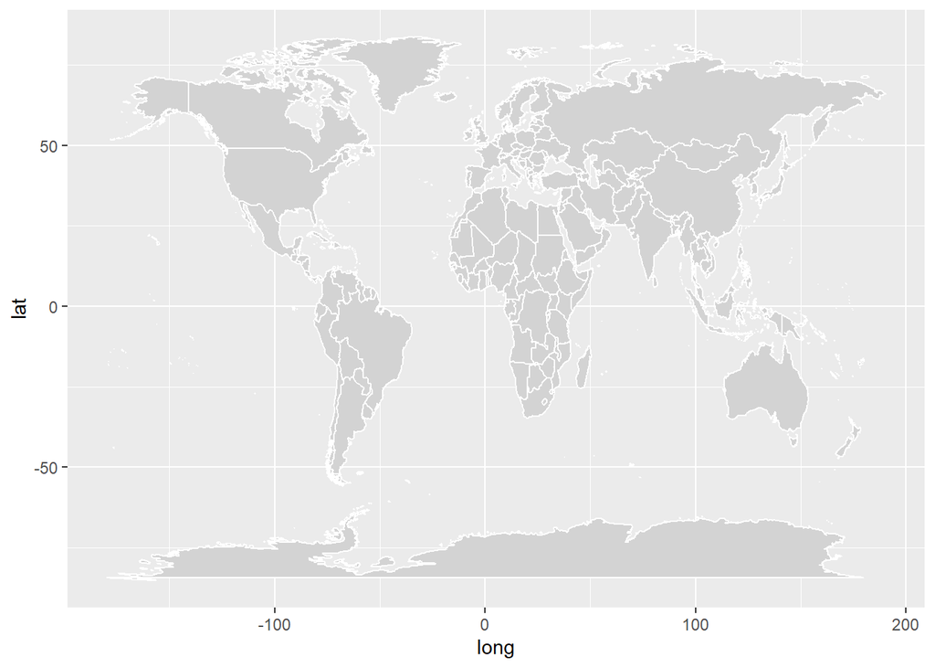

```r
world_map <- map_data("world")
ggplot(world_map, aes(x = long, y = lat, group = group)) +
  geom_polygon(fill="lightgray", colour = "white")
```

See what happens if you replace ‘colour = “white”’ with “colour =”red” ’

And a map of the US, without any state/county borders drawn:

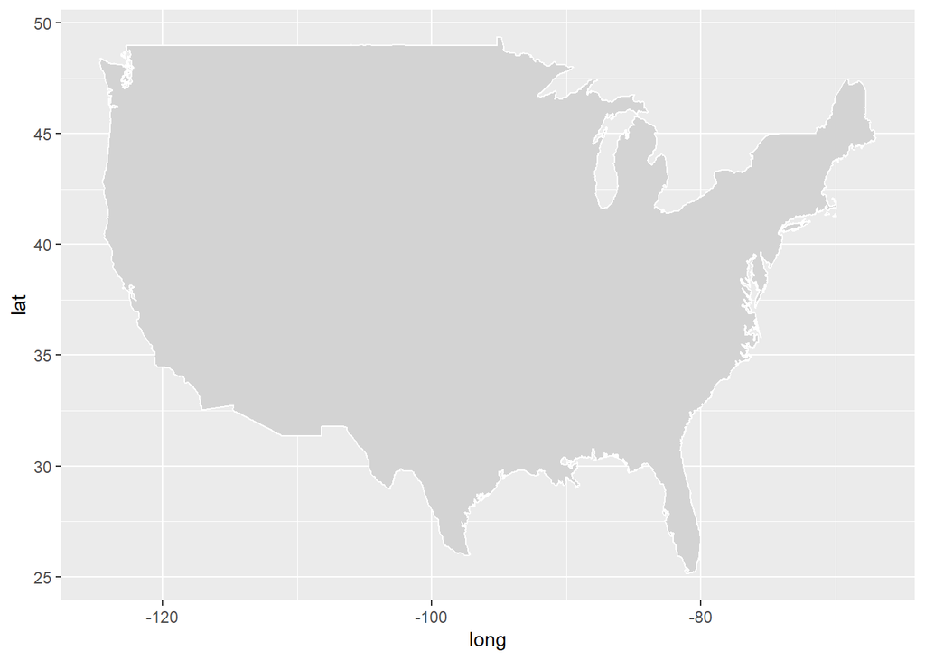

```r
usa_map <- map_data("usa")
ggplot(usa_map, aes(x = long, y = lat, group = group)) +
  geom_polygon(fill="lightgray", colour = "white")
```

Adding the states borders and changing the aspect ratio a notch:

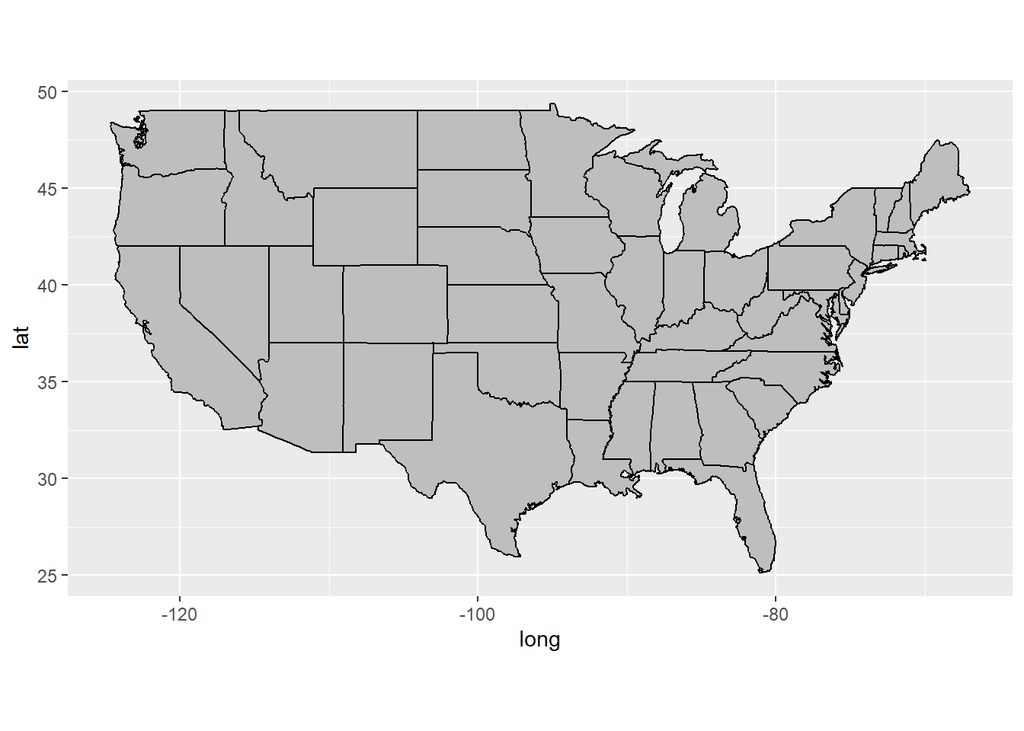

```r
usa <- map_data("state")

usa_map <- ggplot(data=usa, mapping=aes(x=long, y=lat, group=group)) +
  coord_fixed(1.3) +
  geom_polygon(color="black", fill="grey")

plot(usa_map)
```

Zooming on the state of Mississippi + county borders:

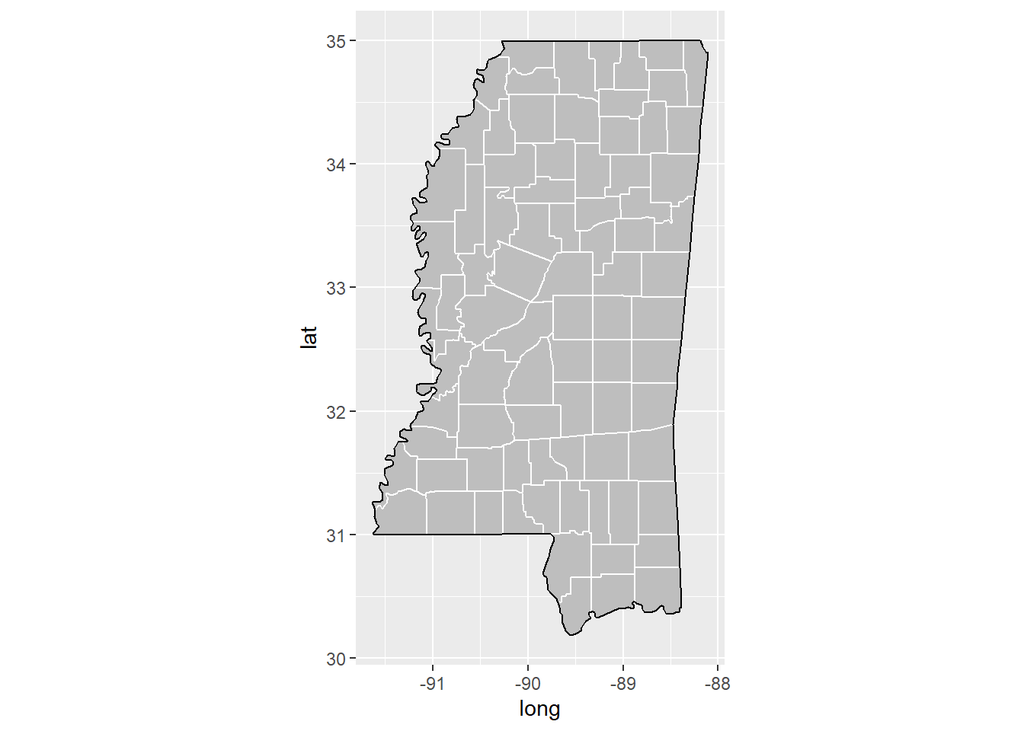

```r
usa <- map_data('state')
ms <- subset(usa, region=="mississippi")

counties <- map_data("county")
ms_counties <- subset(counties, region=="mississippi")

myMap <- ggplot(data=ms, mapping=aes(x=long, y=lat, group=group)) +
  coord_fixed(1.3) +
  geom_polygon(data=ms_counties, fill="grey", color="white") +
  geom_polygon(color="black", fill=NA)


plot(myMap)
```

### Adding points based on geographical coordinates.

In this first exercise, we will add to a usmap a number of points defined by geographical coordinates (longitude and latitude). To illustrate this principle, I will plot the location of the 3 places that I’ve lived in (in the US) with dots of size proportional to the amount of time that I’ve spent in each city.

Let’s start by creating a data.frame containing all this information:

```r
places <- data.frame(
  longitude = c(-86.52, -111.89, -88.73),
  latitude = c(39.15,  33.46, 33.35),
  years = c(7, 1, 6),
  labels = c("Bloomington, IN", "Phoenix, AZ", "Starkville, MS")
)
```

Note how longitudes West of the Greenwitch meridian are negative values.

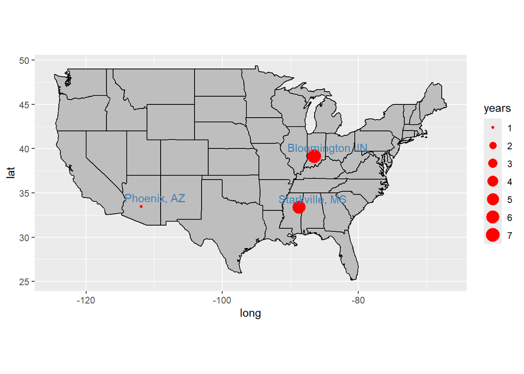

```r
usa <- map_data("state")

usa_map <- ggplot(data=usa, mapping=aes(x=long, y=lat, group=group)) +
  coord_fixed(1.3) +
  geom_polygon(color="black", fill="gray") +
  geom_polygon(data=usa, fill=NA, color="white") +
  geom_polygon(color="black", fill=NA)

mapWithCities <- usa_map + geom_point(data=places, aes(x=longitude, y=latitude, size=years), col="red", inherit.aes = F)

mapWithCities + geom_text(data = places, aes(label = labels, x = longitude+2, y = latitude+1), inherit.aes = F, col="steelblue")
```

Take a minute to generate a map of the places you’ve lived in (or places you like most in the US). Try to adjust the location of labels so that they are nicely positioned relatively to the dots on the map.

### Saguaro data

Let’s look at some more biologically-relevent data. The file saguaros.csv contains the list of saguaro cactus observations reported in the [iNaturalist.org](https://www.inaturalist.org/) website.

A short note: [iNaturalist.org](https://www.inaturalist.org/) is an app (with corresponding website) allowing users to report observations of fauna and flora. It is sometimes used by researchers.  
If you are not familiar with **saguaros**, they are the most majestic type of cactus, frequently seen in the American South-West. Here is an example:

[figure not shown]

.

Download the file to your computer, load it in R and generate a map showing the location of every data point in this file. Here is the code to perform this task:

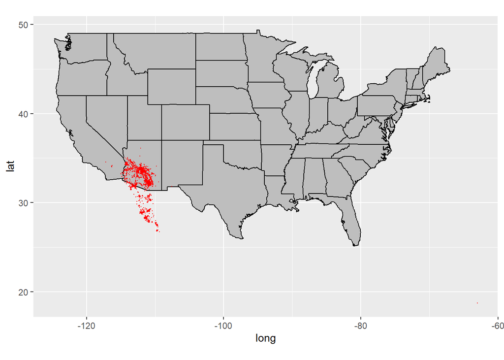

```r
# Reading the csv file:
saguaro = read.csv("./saguaros.csv")

# Removing missing data (observations with no longitude/latitude information)
saguaro = saguaro[which(is.na(saguaro$longitude)==F & is.na(saguaro$latitude)==F ) , ]

# Setting the number of observations to one for each report.
saguaro$nb = 1

# Plot transformed data on map
usa <- map_data("state")

usa_map <- ggplot(data=usa, mapping=aes(x=long, y=lat, group=group)) +
  coord_fixed(1.3) +
  geom_polygon(color="black", fill="gray") +
  geom_polygon(data=usa, fill=NA, color="white") +
  geom_polygon(color="black", fill=NA)

mapWithSaguaro <- usa_map + geom_point(data=saguaro, aes(x=longitude, y=latitude), col="red", size=0.1, inherit.aes = F)

plot(mapWithSaguaro)
```

Notice how data points outside of the US (in Mexico) end up being drawn over a void region. It’s time to zoom out and plot maps of the entire world…

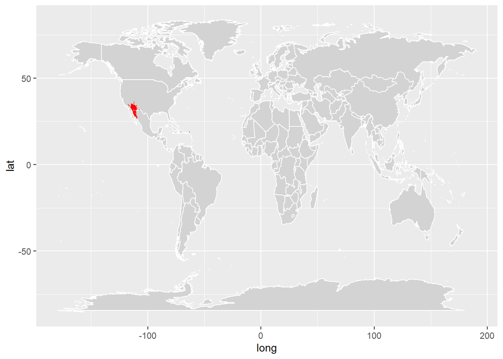

```r
world_map <- map_data("world")
world_map <- ggplot(world_map, aes(x = long, y = lat, group = group)) +
  geom_polygon(fill="lightgray", colour = "white")

mapWithSaguaro <- world_map + geom_point(data=saguaro, aes(x=longitude, y=latitude), col="red", size=0.1, inherit.aes = F)

plot(mapWithSaguaro)
```

### Exercise:

Download the file aligators-MS.csv which contains the location of all iNaturalist reported observations of alligators in the state of Mississippi. Write some R code to generate a map showing the location of these observations.

Display observations as dots on the map. Here is what the result should look like:

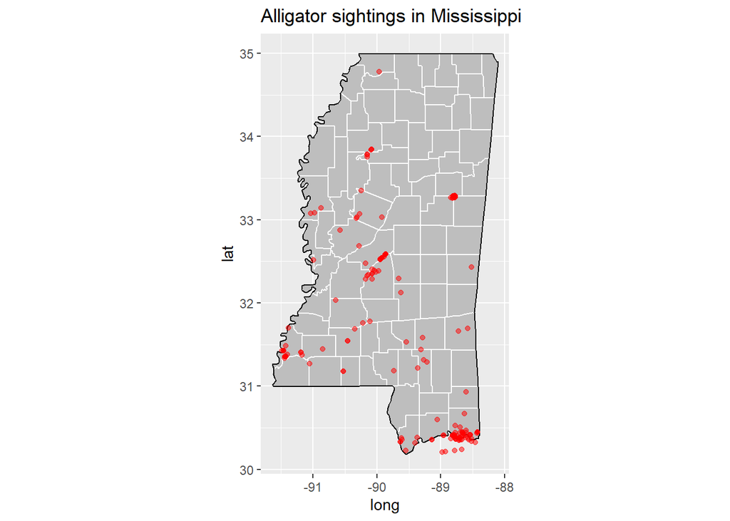